# Rにおける効率的な分析

石田基広

2019年09月03日

# 第二部

## 分析の効率化

- 探索的データ分析
- 機械学習
  - スライド掲載のコードと出力は一致しない場合があります

## 探索的データ分析

- 水準ごとに回帰分析
- 回帰分析の結果をテーブルに

## gapminder

```r
gap <- gapminder %>%
  filter(country %in%
  c("Japan", "China", "Korea, Rep."))
```

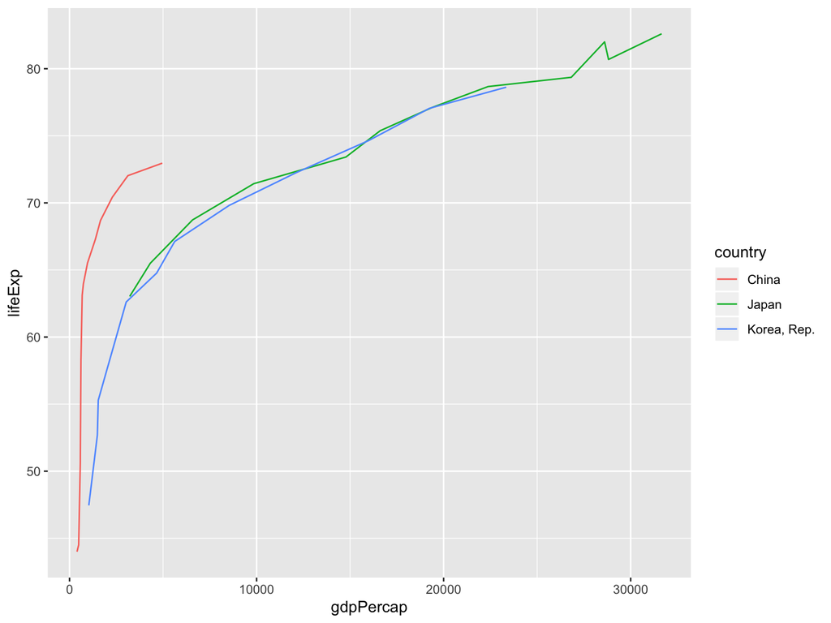

```r
p <- gap %>%
  ggplot() +
  aes(gdpPercap,
      lifeExp,
      col = country) +
  geom_line()
```

## 相関係数

国を分けて相関係数

| 国名 | 相関係数 |
| --- | --- |
| 日本 | cor日本X, 日本Y) |
| 中国 | cor(中国X, 中国Y) |
| 韓国 | cor(韓国X, 韓国Y) |

## 相関係数

国を分けて相関係数

```r
gap %>% filter(country=="China") %>%
  select(gdpPercap, lifeExp) %>% cor()

gap %>% filter(country=="Korea, Rep.")%>%
  select(gdpPercap, lifeExp) %>% cor()

gap %>% filter(country=="Japan") %>%
  select(gdpPercap, lifeExp) %>% cor()
```

## 相関の検定

中国の場合

```r
gap %>% filter(country == "China") %>%
  cor.test(data=., ~lifeExp +gdpPercap)
```

```
    Pearson's product-moment correlation

data:  lifeExp and gdpPercap
t = 3.0991, df = 10, p-value = 0.01127
alternative hypothesis: true correlation is not equal to 0
95 percent confidence interval:
 0.2106440 0.9087826
sample estimates:
      cor
0.6999316
```

## map tidy

```r
gap %>%  nest(-country) %>%
  mutate(test = map(data,
          ~cor.test(data=.,
              ~ lifeExp + gdpPercap)),
          res = map(test, tidy)) %>%
              unnest(res, .drop = TRUE)
```

```
# A tibble: 3 x 9
  country estimate statistic p.value parameter conf.low conf.high method
  <fct>      <dbl>     <dbl>   <dbl>     <int>    <dbl>     <dbl> <chr>
1 China      0.700      3.10 1.13e-2        10    0.211     0.909 Pears…
2 Japan      0.979     15.3  2.95e-8        10    0.925     0.994 Pears…
3 Korea,…    0.903      6.63 5.87e-5        10    0.682     0.973 Pears…
# … with 1 more variable: alternative <chr>
```

## 仕組み

nestで水準ごとに分けたdat列を生成

```r
gap %>% nest(-country)
```

```
# A tibble: 3 x 2
  country     data
  <fct>       <list>
1 China       <tibble [12 × 5]>
2 Japan       <tibble [12 × 5]>
3 Korea, Rep. <tibble [12 × 5]>
```

## 仕組み

dataの中身

```r
gap %>% nest(-country) %>%
              select(data) %>% unnest()
```

```
# A tibble: 36 x 5
   continent  year lifeExp        pop gdpPercap
   <fct>     <int>   <dbl>      <int>     <dbl>
 1 Asia       1952    44    556263527      400.
 2 Asia       1957    50.5  637408000      576.
 3 Asia       1962    44.5  665770000      488.
 4 Asia       1967    58.4  754550000      613.
 5 Asia       1972    63.1  862030000      677.
 6 Asia       1977    64.0  943455000      741.
 7 Asia       1982    65.5 1000281000      962.
 8 Asia       1987    67.3 1084035000     1379.
 9 Asia       1992    68.7 1164970000     1656.
10 Asia       1997    70.4 1230075000     2289.
# … with 26 more rows
```

## map

dataごとに平均を求めてAVG列に追加

```r
gap %>%  nest(-country) %>%
 mutate(AVG=map(data,~mean(.$lifeExp)))
```

```
# A tibble: 3 x 3
  country     data              AVG
  <fct>       <list>            <list>
1 China       <tibble [12 × 5]> <dbl [1]>
2 Japan       <tibble [12 × 5]> <dbl [1]>
3 Korea, Rep. <tibble [12 × 5]> <dbl [1]>
```

## 仕組み

purrr::mapは複数のデータセットそれぞれに関数を適用する

```r
list(x = 1:3, y=1:6, z= 1:10) %>%
  map(mean)
```

```
$x
[1] 2

$y
[1] 3.5

$z
[1] 5.5
```

## 無名関数

```r
list(x = 1:3, y=1:6, z= 1:10) %>%
  map(mean)
list(x = 1:3, y=1:6, z= 1:10) %>%
  map(~mean(.))
```

ドットがデータを表す

```
~mean(.) -> function(.x){mean(.x)}
```

## map_func

処理例：あるフォルダのCSVファイルを全部読み込んで結合する

```r
dat <-list.files(pattern = "*.csv")%>%
          map_df(read_csv)
```

list.files(pattern = "*.csv"でフォルダのcsvファイルの一覧を取り

map_dfでそのリストの要素一つ一つに read_csv を適用して結合

## 仕組み

AVG列をunnestで展開

```r
gap %>%  nest(-country) %>%
       mutate(AVG = map(data,
                ~ mean(.$lifeExp))) %>%
            unnest(AVG)
```

```
# A tibble: 3 x 3
  country     data                AVG
  <fct>       <list>            <dbl>
1 China       <tibble [12 × 5]>  61.8
2 Japan       <tibble [12 × 5]>  74.8
3 Korea, Rep. <tibble [12 × 5]>  65.0
```

## 回帰

```r
gap %>% filter(country == "Japan") %>%
  lm(data=., lifeExp ~ gdpPercap) %>%
     summary()
```

```
Call:
lm(formula = lifeExp ~ gdpPercap, data = .)

Residuals:
    Min      1Q  Median      3Q     Max
-2.6739 -0.9849  0.4094  1.0194  1.5639

Coefficients:
             Estimate Std. Error t value Pr(>|t|)
(Intercept) 6.368e+01  8.316e-01   76.58 3.52e-15 ***
gdpPercap   6.277e-04  4.111e-05   15.27 2.95e-08 ***
---
Signif. codes:  0 '***' 0.001 '**' 0.01 '*' 0.05 '.' 0.1 ' ' 1

Residual standard error: 1.381 on 10 degrees of freedom
Multiple R-squared:  0.9589,    Adjusted R-squared:  0.9548
F-statistic: 233.1 on 1 and 10 DF,  p-value: 2.949e-08
```

## 回帰

出力表に変える：broom::tidy

```r
gap %>% filter(country == "Japan") %>%
  lm(data=.,lifeExp ~ gdpPercap) %>%
    summary() %>% tidy()
```

```
# A tibble: 2 x 5
  term         estimate std.error statistic  p.value
  <chr>           <dbl>     <dbl>     <dbl>    <dbl>
1 (Intercept) 63.7      0.832          76.6 3.52e-15
2 gdpPercap    0.000628 0.0000411      15.3 2.95e- 8
```

回帰の結果を整頓した形式で保存

## 回帰

```r
gap %>% nest(-country) %>%
 mutate(fit = map(data, ~
  lm(data=., lifeExp ~ gdpPercap)),
  res = map(fit, tidy)) %>% unnest(res)
```

```
# A tibble: 6 x 6
  country     term         estimate std.error statistic  p.value
  <fct>       <chr>           <dbl>     <dbl>     <dbl>    <dbl>
1 China       (Intercept) 54.0      3.35          16.1  1.76e- 8
2 China       gdpPercap    0.00523  0.00169        3.10 1.13e- 2
3 Japan       (Intercept) 63.7      0.832         76.6  3.52e-15
4 Japan       gdpPercap    0.000628 0.0000411     15.3  2.95e- 8
5 Korea, Rep. (Intercept) 55.3      1.97          28.1  7.53e-11
6 Korea, Rep. gdpPercap    0.00118  0.000178       6.63 5.87e- 5
```

## コードの意味

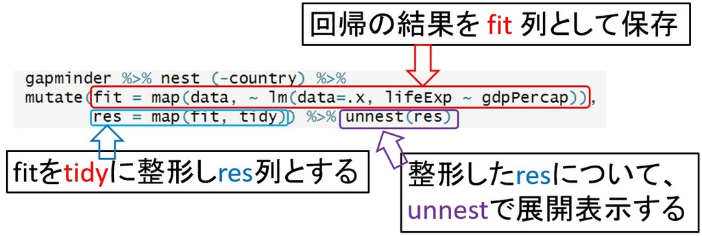

## 要約

```r
gap %>% nest(-country) %>%
  mutate(fit = map(data,
    ~ lm(data=., lifeExp ~ gdpPercap)),
      res = map(fit, tidy),
    glanced = map(fit, glance),
    augmented = map(fit, augment))
```

```
# A tibble: 3 x 6
  country    data          fit    res          glanced       augmented
  <fct>      <list>        <list> <list>       <list>        <list>
1 China      <tibble [12 … <lm>   <tibble [2 … <tibble [1 ×… <tibble [12 ×…
2 Japan      <tibble [12 … <lm>   <tibble [2 … <tibble [1 ×… <tibble [12 ×…
3 Korea, Re… <tibble [12 … <lm>   <tibble [2 … <tibble [1 ×… <tibble [12 ×…
```

## コードの意味

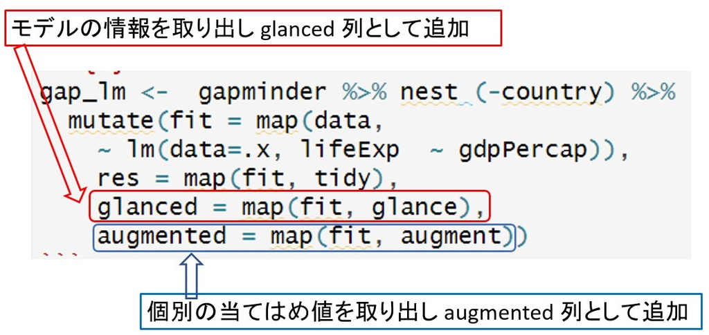

## glance

モデルの詳細情報

```r
gap_lm %>% unnest(glanced,.drop = TRUE)
```

```
# A tibble: 3 x 12
  country r.squared adj.r.squared sigma statistic p.value    df logLik
  <fct>       <dbl>         <dbl> <dbl>     <dbl>   <dbl> <int>  <dbl>
1 China       0.490         0.439  7.68      9.60 1.13e-2     2  -40.4
2 Japan       0.959         0.955  1.38    233.   2.95e-8     2  -19.8
3 Korea,…     0.815         0.796  4.55     43.9  5.87e-5     2  -34.1
# … with 4 more variables: AIC <dbl>, BIC <dbl>, deviance <dbl>,
#   df.residual <int>
```

## augment

モデルに基づく観測値の予測

```r
gap_lm %>% unnest(augmented,.drop = TRUE)
```

```
# A tibble: 36 x 10
   country lifeExp gdpPercap .fitted .se.fit .resid   .hat .sigma .cooksd
   <fct>     <dbl>     <dbl>   <dbl>   <dbl>  <dbl>  <dbl>  <dbl>   <dbl>
 1 China      44        400.    56.1    2.88 -12.1  0.141    6.83 0.236
 2 China      50.5      576.    57.0    2.70  -6.46 0.124    7.76 0.0570
 3 China      44.5      488.    56.5    2.79 -12.0  0.132    6.85 0.215
 4 China      58.4      613.    57.2    2.66   1.18 0.120    8.08 0.00184
 5 China      63.1      677.    57.5    2.61   5.58 0.115    7.85 0.0389
 6 China      64.0      741.    57.9    2.55   6.09 0.110    7.80 0.0439
 7 China      65.5      962.    59.0    2.39   6.49 0.0967   7.77 0.0424
 8 China      67.3     1379.    61.2    2.22   6.06 0.0839   7.81 0.0312
 9 China      68.7     1656.    62.7    2.23   6.03 0.0847   7.82 0.0312
10 China      70.4     2289.    66.0    2.60   4.45 0.114    7.94 0.0245
# … with 26 more rows, and 1 more variable: .std.resid <dbl>
```

# 機械学習

## 一般的な手順

- データを訓練用（および検証用）とテスト用に分割
  - データを標準化（主成分化）
- 分析手法に固有のパラメータ探索
- 訓練データにモデルを学習
- 学習モデルでテストデータを検証

## メソッドの統一

R

```r
# fit方法はそれぞれ
stats::glm(Y~X,
    "binomial")
kernlab::ksvm(Y~X)
# predictは共通
predict(testX)
```

Python

```r
# ロジスティック
clf1 = Lasso()
# サポートベクタ
clf2 = svm.SVC()
# fitで統一
clf1.fit(X, y)
# 予測
clf1.predict(testX)
```

## Python Pipeline

```r
pipeline = Pipeline(
  [('vec',CountVectorizer()),
    ('clf', SGDClassifier()),])
parameters = {
    'vec__ngram_range': ((1, 1), (1, 2)),
    'clf__alpha': (0.00001, 0.000001),}
grid_search = GridSearchCV(pipeline,
      parameters, n_jobs=-1, verbose=1)
grid_search.fit(X, y)
```

## テキスト分析

奈良先端科学技術大学院大学鈴木優氏 http://bigdata.naist.jp/~ysuzuki/data/twitter/

[figure not shown]

## Tweetsを取得

Tweetsのstatus_idと、その評価のデータ(Tweets本文は取得する必要あり）

```r
library(rtweet)
iPhone <- tw_lists %>% select(status_id) %>%
            pull() %>% lookup_tweets()
```

## 評判分析とは

ポジティブな投稿

```r
iPhone_tweets %>% slice(14) %>% select(text) %>% pull()
```

```
[1] "iPhone6でかいからいけるぞ"
```

ネガティブな投稿

```r
iPhone_tweets %>% slice(13) %>% select(text) %>% pull()
```

```
[1] "iPhone6でかすぎ"
```

## 予測モデル

メッセージに出現する単語から、内容がポジティブかネガティブかを二値判定

- 肯定的か否定的 ~ Word1 + Word2 + … + Word9999 + Word10000

## データの用意

status_idごとに出現単語とその頻度

```r
iPhone_df %>% arrange(TERM, status_id)
```

```
# A tibble: 18,247 x 3
   status_id          TERM             n
   <chr>              <chr>        <int>
 1 703580075891884032 あっという間     1
 2 697419801073831936 いい加減         1
 3 551308290882154498 お陰             1
 4 631470217957224449 お陰             1
 5 704299116335992832 お家             1
 6 569511238411030529 お願い           1
 7 579920270888083456 お願い           1
 8 691241852272422912 お願い           1
 9 694381603263393792 お願い           1
10 696548443322318848 お願い           1
# … with 18,237 more rows
```

## 機械学習用messyデータ

```r
iPhone %>% dim()
```

```
[1] 5344 1437
```

## 機械学習の手法

- 罰則項付きロジスティック回帰 (*glmnet*)
- サポートベクターマシン (*kernlab*)
- 決定木 (*rpart*)
- ランダムフォレスト (*randomForest*)
- XGBoost (*xgboost*)

## ロジスティック回帰

評判（１か０）を単語頻度で回帰

```r
# 評価内訳
table(iPhone$Y)
```

```
FALSE  TRUE
 3503  1841
```

```r
# Y ~ .（説明変数全体）
iPhone_glm <- glm(
 Y ~ .,
 data= iPhone,
 family = "binomial")
```

## ロジスティック回帰

単語それぞれが独立した説明変数になる

```r
library(broom)
iPhone_glm %>% tidy()
```

```
# A tibble: 1,303 x 5
   term        estimate  std.error statistic  p.value
   <chr>          <dbl>      <dbl>     <dbl>    <dbl>
 1 (Intercept)   -0.677     0.0574 -11.8     4.25e-32
 2 janetter     -19.2   10754.      -0.00179 9.99e- 1
 3 jojo          18.4   10754.       0.00171 9.99e- 1
 4 Kindle        17.4    1778.       0.00981 9.92e- 1
 5 KREVA        -17.1   10754.      -0.00159 9.99e- 1
 6 line         -19.2   10754.      -0.00179 9.99e- 1
 7 LIVE         -24.9    5367.      -0.00465 9.96e- 1
 8 ll           -19.7    7334.      -0.00268 9.98e- 1
 9 lP           -34.9   12567.      -0.00278 9.98e- 1
10 m             -9.67   1953.      -0.00495 9.96e- 1
# … with 1,293 more rows
```

## P値からキーワード

```r
iPhone_glm %>% tidy() %>%
  filter(p.value < .01) %>%
    arrange(p.value)
```

```
# A tibble: 16 x 5
   term        estimate std.error statistic  p.value
   <chr>          <dbl>     <dbl>     <dbl>    <dbl>
 1 (Intercept)   -0.677    0.0574    -11.8  4.25e-32
 2 画質           3.61     0.471       7.66 1.85e-14
 3 ん            -0.799    0.116      -6.87 6.30e-12
 4 認証           1.76     0.303       5.82 5.81e- 9
 5 デカ          -1.27     0.248      -5.14 2.74e- 7
 6 s              0.358    0.0742      4.82 1.41e- 6
 7 最高           2.61     0.617       4.23 2.37e- 5
 8 手            -0.844    0.225      -3.76 1.73e- 4
 9 感じ           1.26     0.365       3.44 5.79e- 4
10 性能           3.73     1.14        3.27 1.09e- 3
11 ピンク         1.69     0.525       3.22 1.30e- 3
12 音質           3.28     1.05        3.13 1.73e- 3
13 反応          -1.13     0.413      -2.75 5.97e- 3
14 バッテリー    -0.542    0.198      -2.74 6.18e- 3
15 S              0.345    0.130       2.66 7.85e- 3
16 回線           1.56     0.592       2.64 8.27e- 3
```

## 回帰による予測精度

混合行列で確認

```r
preds <- round(
 predict(iPhone_glm,
type="response"))
```

```r
table(preds,
      iPhone$Y)
```

```
preds FALSE TRUE
    0  3339  897
    1   164  944
```

## 汎化モデル

- バイアス（真の値との差）
  - モデルを複雑すると減少
  - ただし汎用性がなくなる
- バリアンス（予測値のばらつき）
  - モデルが簡素化すると減少
  - ただし予測精度は落ちる

## 汎化モデル

- データ全部を使わない
  - 訓練データで候補モデルを調整
  - テストデータで予測精度
- モデル特有のハイパーパラメータ

## caret_vignettes

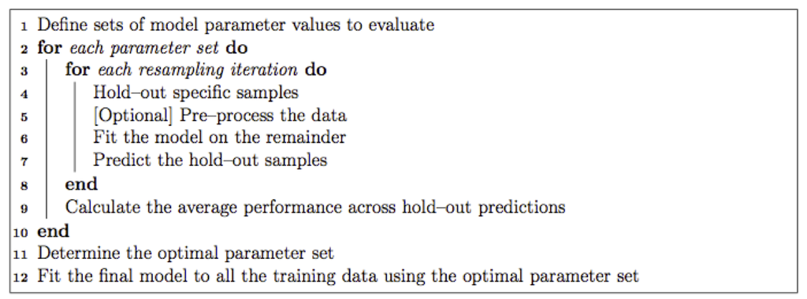

## ロジスティック回帰の場合

- 回帰係数 $\beta$ を調整するハイパーパラメータ
- 複雑さ指標 $\lambda$ ：小さいほど複雑なモデル（0だとOLS）
- $\alpha$ が1の場合 $\beta$ の一部は正確に 0 に: L１正則化
- $\alpha$ が0の場合 $\beta$ は 0に近づく: L2正則化

## データの分割

```r
index <- sample(
   N, N * 0.7)
train <-dat[index,]
test <- dat[-index,]
```

```r
index <- caret::
createDataPartition
 (y = dat$Y,
   p = 0.7)
train <-dat[ index,]
test  <-dat[-index,]
```

## Lasso回帰

L1正則化：glmnetパッケージ

```r
# 訓練データから目的変数を抽出行列化
train_X <- training %>% select(-Y) %>%
  as.matrix(dimnames = #列名（単語）を残す
              list(NULL, colnames(.)))
# 目的変数をベクトルに
train_Y <- training$Y
# テストデータにも適用
test_X <- testing %>% select(-Y) %>%
  as.matrix(dimnames = list(NULL, colnames(.))) #列名（単語）を残す
test_Y <- testing$Y
```

## Lasso回帰

```r
lasso <- glmnet(
  x = train_X,
  y = train_Y,
  family="binomial",
   parallel = TRUE)
```

[figure not shown]

## 推定結果

最適な $\lambda$ の値

```r
lasso$lambda.min; lasso$lambda.1se
```

```
[1] 0.005750368
```

```
[1] 0.009156212
```

## 予測精度

```r
las_pr <-predict(lasso,newx = test_X,
                       type = "class")
confusionMatrix(table(las_pr, test_Y))
```

```
Confusion Matrix and Statistics

       test_Y
las_pr  FALSE TRUE
  FALSE  1006  434
  TRUE     44  118

               Accuracy : 0.7016
                 95% CI : (0.6786, 0.724)
    No Information Rate : 0.6554
    P-Value [Acc > NIR] : 4.688e-05

                  Kappa : 0.2065

 Mcnemar's Test P-Value : < 2.2e-16

            Sensitivity : 0.9581
            Specificity : 0.2138
         Pos Pred Value : 0.6986
         Neg Pred Value : 0.7284
             Prevalence : 0.6554
         Detection Rate : 0.6280
   Detection Prevalence : 0.8989
      Balanced Accuracy : 0.5859

       'Positive' Class : FALSE
```

## 予測精度の指標

- 感度(Sensitivity)：再現率
- 特異度(Specificity)
- 正解度 (Accurarcy)
- 精度(Precision) ：適合率

|  | 予測が真 | 予測が偽 |
| --- | --- | --- |
| 実際に真 | 真陽性(TP) | 偽陰性(FN) |
| 実際に偽 | 偽陽性(FP) | 真陰性(TN) |

## ROC

感 度（真陽性率）: 実際に T であるケースでTと予測された割合

特異度（真陰性率）: 実際に F であるケースでFと予測された割合

- 問題は判断の閾値

## ROC

```r
library(pROC)
lasso_res <-
  predict(
   lasso,
   s="lambda.min",
  newx =test_X,
  type ="response")
lasso_roc <-
  roc(test_Y,
   lasso_res)
```

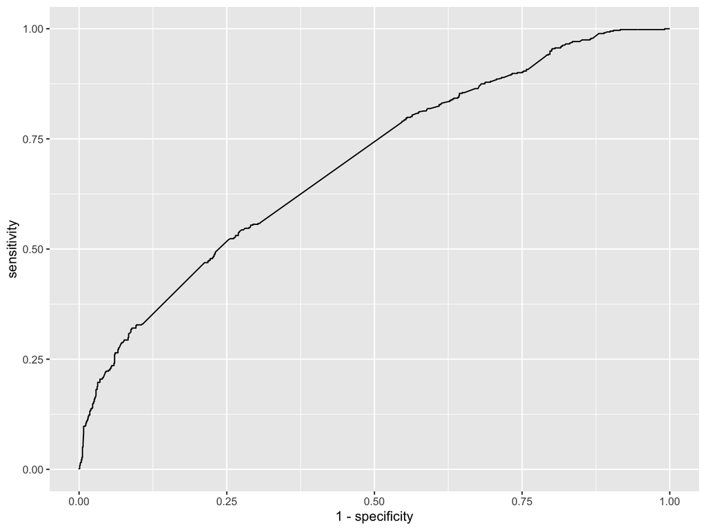

```r
ggroc(lasso_roc,
 legacy.axes=TRUE)
```

## Method_auc

AUC基準で最良のモデルを推定する指定

```r
lasso_cv_auc <- cv.glmnet(x = X, y = y,
  type.measure = "auc",#aucを指定
  alpha = 1, family = "binomial")
```

## サポートベクター

非線形の GaussianRBF (rbfdot) でクラス分類(C-svc)、10交差法：

```r
library(kernlab)
svm_kernlab  <- ksvm(Y ~ .,
      data = training, scaled = FALSE,
      kernel="rbfdot", type="C-svc",
      cross = 10)
```

## メソッドの統一

R

```r
# fit方法はそれぞれ
glmnet::glm(Y ~ X,
    "binomial")

kernlab::ksvm(
  Y ~ X, C=1)
```

Python

```r
clf1 = Lasso()
clf2 = svm.SVC()
# メソッドは統一
clf1.fit(X, y)
clf2.fit(X, y)
```

## さまざまなモデルを試行

手法（パッケージ）の違いを吸収： *caret*, *mlr*, *tidymodels*

## *caret*

```r
caret::train(
    x = 説明変数
  , y = 目的変数
  , method = 分析手法
  , tuneGrid = モデルパラメータの範囲
  , trControl = 交差法の指定
  , preProcess = データの加工指定
   )
```

## caret

```r
caret::train(
  x = 説明変数,
  y = 目的変数,
  method = 分析手法 ,
  tuneGrid = モデルパラメータの範囲 ,
  trControl = 交差法 , #ここのカンマでエラーに
  # preProcess = データの加工指定 ,
   )
```

## *caret*と*glmnet*

- 係数を調整する $\lambda$や $\alpha$ を $(0,1)$ 範囲で探する
- 交差法の指定： ホールドアウト、K分割交差法、繰り返しK分割交差法
  - パラメータ探索については <sub>tuneLength</sub>でに任せられる

## parameters

パラメータの探索範囲

```r
library(caret)
train_cntrl <-trainControl(
     method = "cv", number = 10,
     classProbs = TRUE,
     summaryFunction = twoClassSummary)
train_grid <- expand.grid(
        alpha  = seq(0, 1.0, by = 0.01) ,
        lambda = 10^(0:10 * -1))
```

## preProcess

データの中心化、標準化、主成分化を指定

```r
preProcess = c("center", "scale")
preProcess = c("pca")#この場合はcenterとscaleも適用される
```

## glmnet

```r
caret::train(Y ~ ., data =training
    , method = "glmnet"
    , tuneGrid = train_grid
    , trControl = train_cntrl
    , metric = "ROC"
    #, preProcess = c("center","scale")
         )
```

## コードの意味

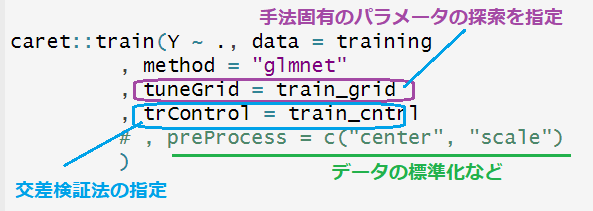

## kernlab

```r
caret::train(Y ~ ., data = training,
    , method = "svmRadial",
    , tuneGrid = expand.grid(C=1:10,
    ,   sigma = seq(0.0, 0.9, by = 0.1),
    , trControl = trainControl(
    ,   method = "cv", number = 10),
   # ,preProcess = c("center","scale")
       )
```

## 複数のモデル当てはめ

```r
my_train <- function(method,formula,data){
   caret::train(formula, data, method
     , trControl = caret::trainControl(
          , method = 'cv')) }
models <- tibble(methods =
        c('lm', 'glmnet', "kernlab"))
models %>% mutate(fits = map(methods,
            train_mds, Y~X, my_train))
```

## tidymodels

caret開発者によるtidy インターフェイス

[figure not shown]

## 複合的なパッケージ

```r
library(tidymodels)
```

`https://static1.squarespace.com/static/51156277e4b0b8b2ffe11c00/t/5b75871e21c67c985a06f481/1534428959053/RPharma_18_Kuhn.pdf`

## *tidymodels*で*glmnet*

データ分割： rsample::initial_split(), training(), testing()

```r
splitted_data <- initial_split(
  iPhone, p = 0.5, strata = c('Y'))
train_data <- training(splitted_data)
test_data <- testing(splitted_data)
```

## recipe

目的変数と説明変数を対応付ける

```r
rec <- recipe(Y ~ ., data = train_data)
```

## step_func

標準化など

```r
#今回は使っていない
rec <- rec %>% step_scale(all_numeric()) %>%
  step_corr(all_numeric(),
              - all_outcomes(),
            threshold = 0.5) %>%
  step_dummy(all_nominal()) #baseRで不要
```

https://cran.r-project.org/web/packages/recipes/vignettes/Dummies.html

## prep

訓練用データに prep() で下ごしらえ

```r
rec_dat <- rec %>% prep(training =
                          train_data)
```

## juice

下ごしらえを訓練用データとテスト用データのそれぞれに適用：juice(), bake()

```r
train_juiced <- rec_dat %>% juice()
test_baked <- rec_dat %>%
  bake(test_data)
```

## set_engine

mixture: $\alpha$ : penalty: $\lambda$

```r
glmnet_model_tidy <-
  logistic_reg(mixture = 1,
               penalty = 10^(0:5 * -1)) %>%
                  set_engine("glmnet")
translate(glmnet_model_tidy)#モデルの確認
```

```
Logistic Regression Model Specification (classification)

Main Arguments:
  penalty = c(1, 0.1, 0.01, 0.001, 1e-04, 1e-05)
  mixture = 1

Computational engine: glmnet

Model fit template:
glmnet::glmnet(x = missing_arg(), y = missing_arg(), weights = missing_arg(),
    alpha = 1, family = "binomial")
```

## fit

準備が整ったらモデルの学習

```r
lasso_tidy <- glmnet_model_tidy %>%
      fit(Y ~ ., data = train_juiced)
```

## predict

ペナルティごとに予測: multi_predict()

```r
preds<-test_baked%>%
 select(Y) %>%
 bind_cols(fitted=
     multi_predict(
    lasso_tidy,
    test_baked))
```

```
# A tibble: 2,671 x 2
   Y     .pred
   <fct> <list>
 1 FALSE <tibble [6 × 2]>
 2 TRUE  <tibble [6 × 2]>
 3 FALSE <tibble [6 × 2]>
 4 TRUE  <tibble [6 × 2]>
 5 TRUE  <tibble [6 × 2]>
 6 TRUE  <tibble [6 × 2]>
 7 TRUE  <tibble [6 × 2]>
 8 TRUE  <tibble [6 × 2]>
 9 TRUE  <tibble [6 × 2]>
10 TRUE  <tibble [6 × 2]>
# … with 2,661 more rows
```

## 予測値の抽出

最初のレコードに対する予測値を確認

```r
preds$.pred[[1]]
```

```
# A tibble: 6 x 2
  penalty .pred
    <dbl> <fct>
1 0.00001 FALSE
2 0.0001  FALSE
3 0.001   FALSE
4 0.01    FALSE
5 0.1     FALSE
6 1       FALSE
```

## 予測値の展開

unnest() を使って .$pred 列を展開

```r
preds_f <- preds %>%
 mutate(.pred =map(
  .pred,bind_rows))%>%
  unnest()
```

```
# A tibble: 16,026 x 3
   Y     penalty .pred
   <fct>   <dbl> <fct>
 1 FALSE 0.00001 FALSE
 2 FALSE 0.0001  FALSE
 3 FALSE 0.001   FALSE
 4 FALSE 0.01    FALSE
 5 FALSE 0.1     FALSE
 6 FALSE 1       FALSE
 7 TRUE  0.00001 FALSE
 8 TRUE  0.0001  FALSE
 9 TRUE  0.001   FALSE
10 TRUE  0.01    FALSE
# … with 16,016 more rows
```

## 予測精度の評価

*yardstick* の各種評価関数

```r
preds_f %>% group_by(penalty) %>%
                     metrics(Y, .pred)
```

```
# A tibble: 12 x 4
   penalty .metric  .estimator .estimate
     <dbl> <chr>    <chr>          <dbl>
 1 0.00001 accuracy binary         0.685
 2 0.0001  accuracy binary         0.686
 3 0.001   accuracy binary         0.691
 4 0.01    accuracy binary         0.701
 5 0.1     accuracy binary         0.656
 6 1       accuracy binary         0.656
 7 0.00001 kap      binary         0.215
 8 0.0001  kap      binary         0.219
 9 0.001   kap      binary         0.221
10 0.01    kap      binary         0.202
11 0.1     kap      binary         0
12 1       kap      binary         0
```

## ランダムフォレスト

rand_forest():

```r
rf_ <- rand_forest(mode = "classification",
    trees = 20, min_n = 100,
    mtry = 1000) %>%
  set_engine("randomForest", seed = 123)
rf_fit <- tf_ %>%
      fit(Y ~ ., data = train_baked)
```

## 複数モデルの当てはめ

```r
rf <- rand_forest(trees = 10,
          mode = "classification") %>%
             set_engine("ranger")
lasso  <- logistic_reg(penalty=1) %>%
 set_engine("glmnet",family="multinomial")
models <- list(rf, lasso)
fitted <- models %>% map(
   ~ fit(.,Y ~ .,data = train))
```

## まとめ

- 探索的分析は
  - map broom caret tidymodels で効率化を
- 退屈な作業はRにやらよう